# Lab 4

Author

Mitchell Anderson

```r
#Question 1
library(data.table)
library(leaflet)
library(tidyverse)
if (!file.exists("met_all.gz"))
  download.file(
    url = "https://raw.githubusercontent.com/USCbiostats/data-science-data/master/02_met/met_all.gz",
    destfile = "met_all.gz",
    method   = "libcurl",
    timeout  = 60
    )
met <- read.csv("met_all.gz",stringsAsFactors = FALSE)
# install.packages('R.utils')
```

```r
#Question 2
#remove temperatures less than -17C
#Make sure there are no missing data in the key variables coded as 9999,999,etc
library(data.table)
setDT(met)
met <- met[temp > -17][elev == 9999.0, elev := NA]

#Generate a data variable using the functions as.Date()
met[, week:=week(as.Date(paste(year, month, day, sep="-")))]

#using the data.table::week function, keep the observations of the first week of the month
met<-met[week==min(week,na.rm=TRUE)]

#compute the mean by station of the variables temp, rh, wind.sp, vis.dist, dew.point, lat, lon, and elev.
met_avg<-met[,.(temp=mean(temp,na.rm=TRUE), rh=mean(rh,na.rm=TRUE),
wind.sp=mean(wind.sp,na.rm=TRUE),
vis.dist=mean(vis.dist,na.rm=TRUE),
dew.point=mean(dew.point, na.rm=TRUE),
lat=mean(lat), lon=mean(lon),
elev=mean(elev,na.rm=TRUE)), by="USAFID"]


#Create a region variable for NW, SW, NE, SE based on lon = -98.00 and lat = 39.71 degrees
met_avg$region<-ifelse(met_avg$lon> -98&met_avg$lat>39.71, "North East",    ifelse(met_avg$lon> -98&met_avg$lat<39.71, "South East",                                                                              ifelse(met_avg$lon< -98&met_avg$lat>39.71,"North West","South West")))

#Create a categorical variable for elevation as in the lecture slides
met_avg$elev_cat<-ifelse(met_avg$elev>252, "High", "Low")
table(met_avg$region)
```

```
North East North West South East South West
       484        146        649        296
```

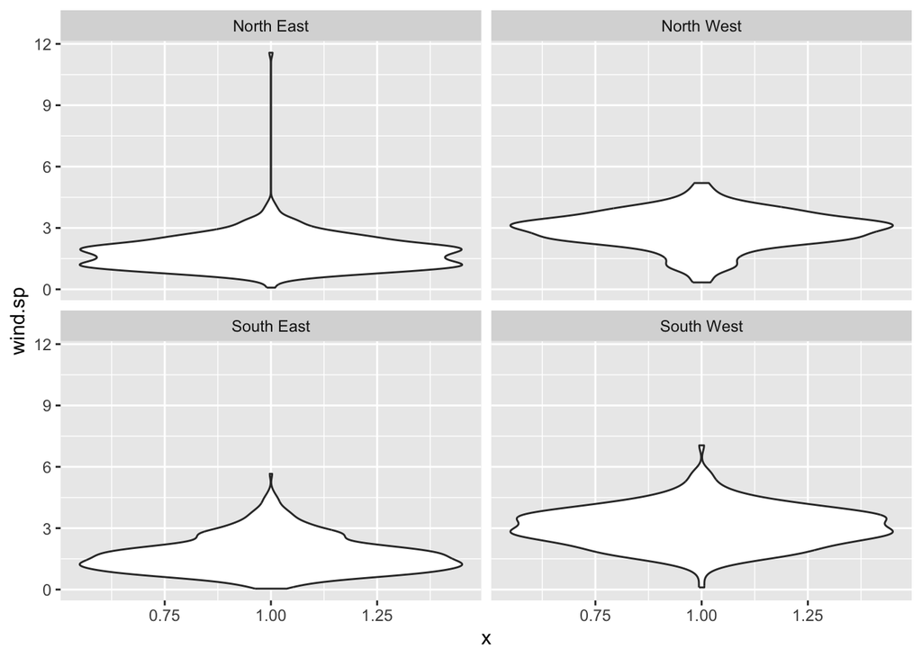

```r
#Question 3
met_avg%>%
  filter(!(region %in% NA))%>%
  ggplot()+
  geom_violin(mapping=aes(y=wind.sp, x=1))+
  facet_wrap(~region,nrow=2)
```

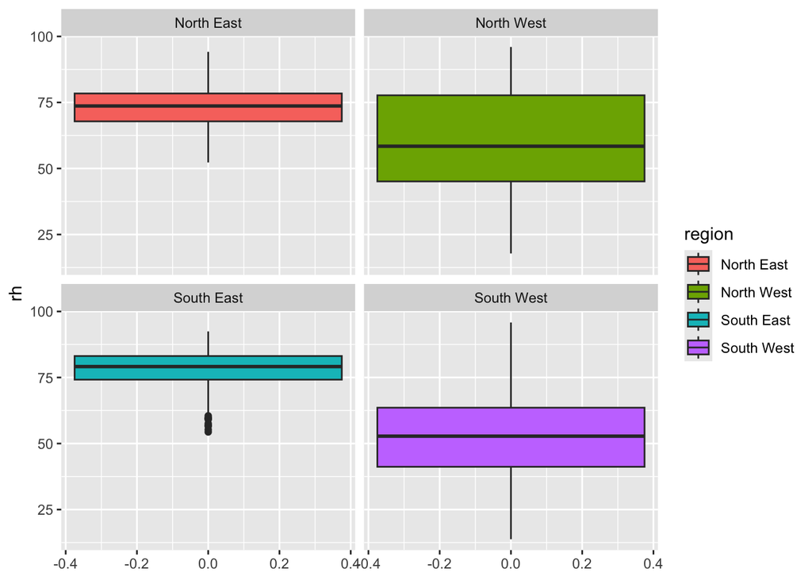

```r
met_avg%>%
  filter(!(region%in% NA))%>%
  ggplot()+
  geom_boxplot(mapping=aes(y=rh,fill=region))+
  facet_wrap(~region,nrow=2)
```

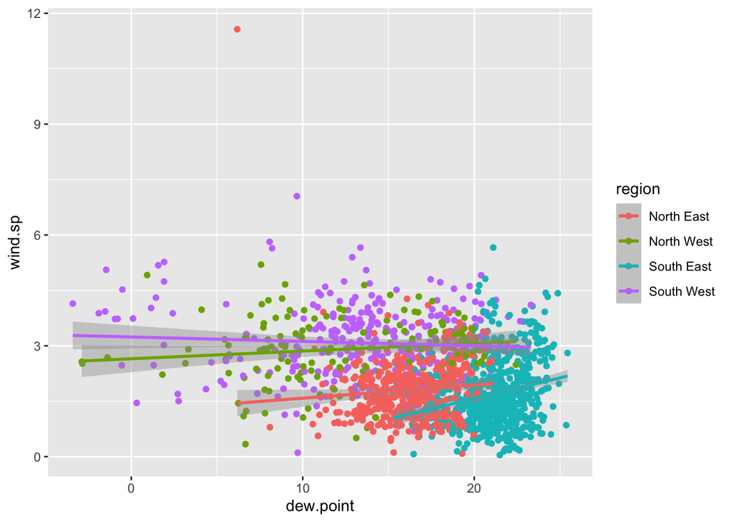

```r
#4
met_avg%>%
  filter(!is.na(dew.point)&!is.na(wind.sp))%>%
  ggplot(mapping=aes(x=dew.point, y=wind.sp, color=region))+
  geom_jitter()+
  stat_smooth(method=lm)
```

The colors of the graph depict the different geographical regions. The y-axis depicts wind speed and the x-axis depicts dew point. The graph displays that ther is a high coexistence of dew point and wind speed in the north and south east. The south western region shows hihg variability of both wind speed and dew point.

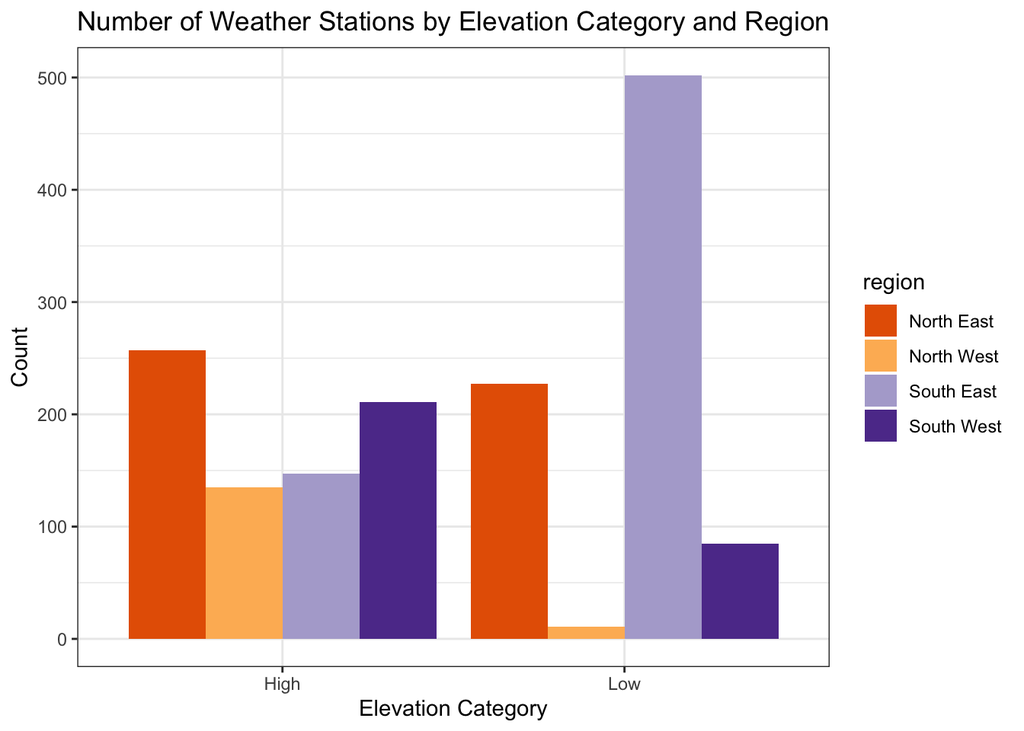

```r
#5
met_avg%>%
  filter(!(elev_cat%in%NA))%>%
  ggplot()+
  geom_bar(mapping=aes(x=elev_cat, fill=region),position="dodge")+
  scale_fill_brewer(palette="PuOr")+
labs(title="Number of Weather Stations by Elevation Category and Region", x="Elevation Category", y="Count") +
  theme_bw()
```

The x-axis contains two “bucket” categories, high or low elevation. The y-axis displays the number of weather stations by region. The graph tells us that the south east region has the most weather stations in the low elevation category and the north west has the least. In the high elevation category, the north east region has the most weather stations and the north west has the least.

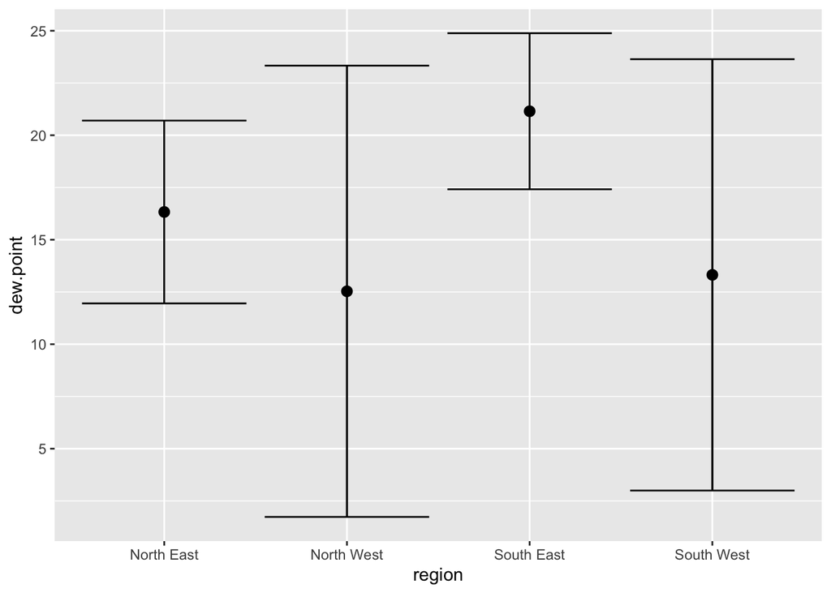

```r
#6
met_avg%>%
  filter(!is.na(dew.point)&!is.na(wind.sp))%>%
  ggplot(mapping=aes(x=region,y=dew.point))+
  stat_summary(fun.data="mean_sdl", geom="errorbar")+
  stat_summary(fun.data="mean_sdl")
```

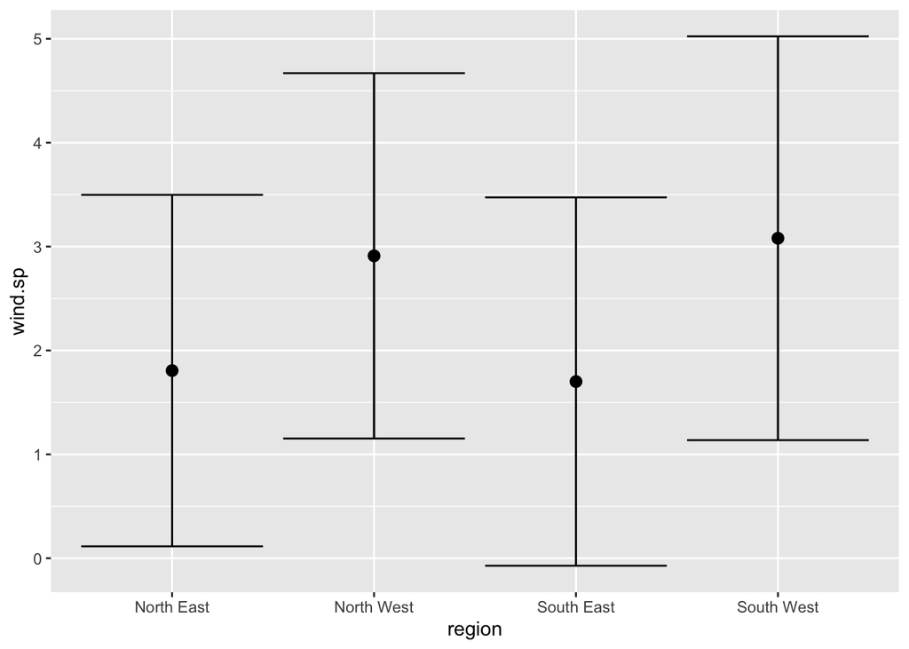

```r
met_avg%>%
  filter(!(region%in%NA))%>%
  ggplot(mapping=aes(x=region,y=wind.sp))+
  stat_summary(fun.data="mean_sdl", geom="errorbar")+
  stat_summary(fun.data="mean_sdl")
```

```r
#7
library(ggplot2)
library(leaflet)
met_avg2 <- met_avg[!is.na(rh)]
top10<-met_avg2[rank(-rh)<=10]

rh_pal= colorNumeric(c('blue','purple','red'), domain = met_avg2$rh)

leaflet(met_avg2)%>%
  addProviderTiles('OpenStreetMap')%>%
  addCircles(lat=~lat,
             lng=~lon,
             color=~rh_pal(rh),
             label=~paste0(round(rh,2),'rh'),
             opacity=1,
             fillOpacity=1,
             radius=500)%>%
  addMarkers(lat=~lat,
             lng=~lon,
             label=~paste0(round(rh,2),' rh'),
             data=top10)%>%
  addLegend('bottomleft',pal=rh_pal,values=met_avg2$rh,
            title="Relative Humidity",opacity=1)
```

[interactive chart not shown]

The leaflet plot of the United States reveals the states in the deep south, or other stations near water, have greater levels of humidity.

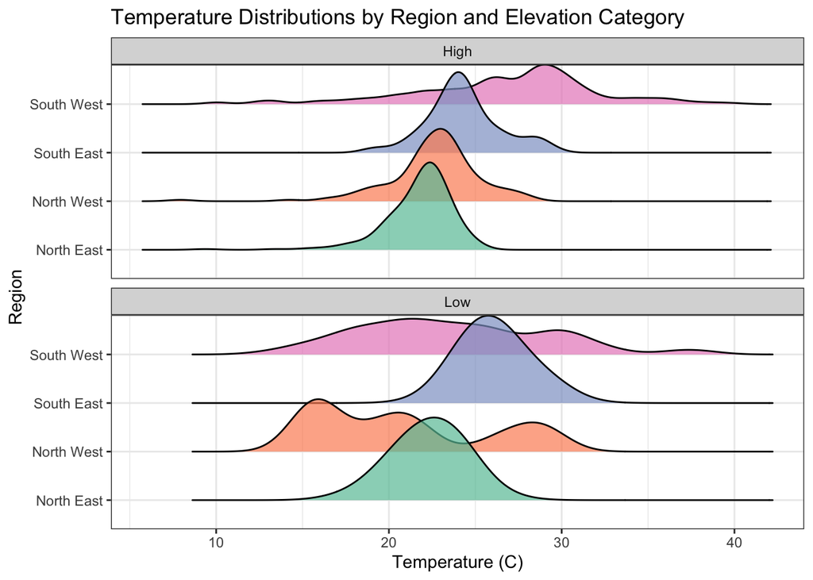

```r
  #8
  library(ggplot2)
  library(ggridges)
library(dplyr)

  met_avg %>%
    filter(!(temp%in%NA)) %>%
    ggplot(mapping=aes(x=temp, y=region, fill=region))+
  geom_density_ridges(alpha=0.7)+
facet_wrap(~elev_cat,nrow=2)+
  scale_fill_brewer(palette="Set2")+
  labs(title="Temperature Distributions by Region and Elevation Category",
       x="Temperature (C)",
       y="Region",
       fill="Region")+
theme_bw()+
  theme(legend.position="Bottom")
```